# Final

## LaMelo Ball: Is the Hype Real?

LaMelo Ball has been a popular name in the basketball world for the past few years. In 2017, he made a name for himself in high school as a Sophomore, scoring 92 points in one game and being part of one of the best high schoool teams in the country. Every sports broadcast was featuring this game, and soon after, the gym during his games became packed with fans. After high school, he took his game to Australia, becoming NBL Rookie of the Year. After one year, he entered the NBA draft and was selected number one overall by the Charlotte Hornets. LaMelo is the first player to be in the splotlight so young in his life, and there was a lot of hype surrounding him coming into his rookie season. We will see if his extraordinary play of his younger years transfers into the NBA. Some have said that LaMelo is the greatest basketball player to into the league since LeBron James (arguably the best player ever).

The question becomes: Does LaMel Ball deserve the hype? Is he really that good?

To learn more about LaMelo Ball and his career so far, you can read this article: https://populartimelines.com/timeline/LaMelo-Ball

```python
import pandas as pd
import numpy as np
import seaborn as sns
import matplotlib.pyplot as plt
import statsmodels.api as sm
from sklearn.linear_model import LinearRegression
```

## Data Scraping I

To start, we need see how to compare LaMelo Ball to other players. Since he is a rookie this year, we only have his rookie stats to compare to other players.

Due to this fact, I will take the statistics from arguably the top 2 greatest players to ever play basketball: LeBron James and Kobe Bryant. I will see how their career stats compare to their rookie season. I am making this comparison because if I see that their worst seasons are their first seasons, I know that I cannot compare LaMelo's rookie statistics with players in the league with many years under their belt. However, if their statistics fluctuate throughout their career, and their rookie season numbers are better than other years in their career, then that means I should be able to compare his LaMelo Ball's game to other great players in the game at the moment.

These statistics were taken from https://www.basketball-reference.com/

```python
lebron_df = pd.read_html('https://www.basketball-reference.com/players/j/jamesle01.html#per_game')[0]
kobe_df = pd.read_html('https://www.basketball-reference.com/players/b/bryanko01.html#per_game')[0]


lebron_df = lebron_df.drop([18,19,20,21,22])
kobe_df = kobe_df.drop([20])

display(lebron_df.head(4))
display(kobe_df.head(4))
```

|  | Season | Age | Team | Lg | Pos | G | GS | MP | FG | FGA | ... | FT% | ORB | DRB | TRB | AST | STL | BLK | TOV | PF | PTS |
| --- | --- | --- | --- | --- | --- | --- | --- | --- | --- | --- | --- | --- | --- | --- | --- | --- | --- | --- | --- | --- | --- |
| 0 | 2003-04 | 19.0 | CLE | NBA | SG | 79.0 | 79.0 | 39.5 | 7.9 | 18.9 | ... | 0.754 | 1.3 | 4.2 | 5.5 | 5.9 | 1.6 | 0.7 | 3.5 | 1.9 | 20.9 |
| 1 | 2004-05 | 20.0 | CLE | NBA | SF | 80.0 | 80.0 | 42.4 | 9.9 | 21.1 | ... | 0.750 | 1.4 | 6.0 | 7.4 | 7.2 | 2.2 | 0.7 | 3.3 | 1.8 | 27.2 |
| 2 | 2005-06 | 21.0 | CLE | NBA | SF | 79.0 | 79.0 | 42.5 | 11.1 | 23.1 | ... | 0.738 | 0.9 | 6.1 | 7.0 | 6.6 | 1.6 | 0.8 | 3.3 | 2.3 | 31.4 |
| 3 | 2006-07 | 22.0 | CLE | NBA | SF | 78.0 | 78.0 | 40.9 | 9.9 | 20.8 | ... | 0.698 | 1.1 | 5.7 | 6.7 | 6.0 | 1.6 | 0.7 | 3.2 | 2.2 | 27.3 |

4 rows × 30 columns

|  | Season | Age | Team | Lg | Pos | G | GS | MP | FG | FGA | ... | FT% | ORB | DRB | TRB | AST | STL | BLK | TOV | PF | PTS |
| --- | --- | --- | --- | --- | --- | --- | --- | --- | --- | --- | --- | --- | --- | --- | --- | --- | --- | --- | --- | --- | --- |
| 0 | 1996-97 | 18.0 | LAL | NBA | SF | 71 | 6 | 15.5 | 2.5 | 5.9 | ... | 0.819 | 0.7 | 1.2 | 1.9 | 1.3 | 0.7 | 0.3 | 1.6 | 1.4 | 7.6 |
| 1 | 1997-98 | 19.0 | LAL | NBA | SF | 79 | 1 | 26.0 | 4.9 | 11.6 | ... | 0.794 | 1.0 | 2.1 | 3.1 | 2.5 | 0.9 | 0.5 | 2.0 | 2.3 | 15.4 |
| 2 | 1998-99 | 20.0 | LAL | NBA | SG | 50 | 50 | 37.9 | 7.2 | 15.6 | ... | 0.839 | 1.1 | 4.2 | 5.3 | 3.8 | 1.4 | 1.0 | 3.1 | 3.1 | 19.9 |
| 3 | 1999-00 | 21.0 | LAL | NBA | SG | 66 | 62 | 38.2 | 8.4 | 17.9 | ... | 0.821 | 1.6 | 4.7 | 6.3 | 4.9 | 1.6 | 0.9 | 2.8 | 3.3 | 22.5 |

4 rows × 30 columns

I printed out the beginning of each dataframe to sese what they look like. Now that we have the data, I will create a scatterplot comparing the points, rebounds, and assists per game per season.

## Data Visualization I

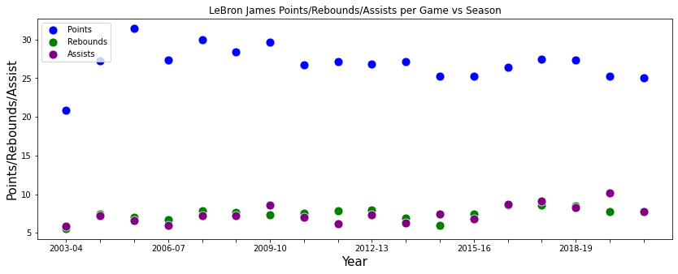

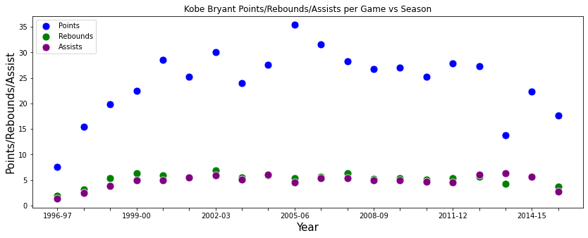

```python
# create list with data for LeBron and Jordon and create graph for each category

player_lst = [[lebron_df, "LeBron James"],\
              [kobe_df, "Kobe Bryant"]]
for player in player_lst:
    fig_dims = (14, 5)
    fig, ax = plt.subplots(figsize=fig_dims)
    sns.scatterplot(data=player[0], x='Season', y='PTS',s=120, color='blue', label="Points")
    sns.scatterplot(data=player[0], x='Season', y='TRB',s=120, color='green', label="Rebounds")
    sns.scatterplot(data=player[0], x='Season', y='AST',s=120, color='purple', label="Assists")
    for index, label in enumerate(ax.xaxis.get_ticklabels()):
        if index % 3 != 0:
            label.set_visible(False)
    plt.title(player[1] + " Points/Rebounds/Assists per Game vs Season")
    plt.legend(loc="upper left")
    plt.xlabel('Year', size=15)
    plt.ylabel("Points/Rebounds/Assist", size=15)
```

We see from the plots that these two players had their worst seasons their rookie seasons. This information is very important because it means we cannot compare LaMelo Ball's season with everyone else this year. LaMelo, as a rookie, needs to be compared to the best rookie players. Every year, the NBA gives the Rookie of the Year award to the best rookie, so I will be using data from the Rookie of the Year for the past 30 years and compare LaMelo Ball to them.

We will be able to see if Lamelo's stats line up or supercede these statistics during their rookie season, and would be a great indication on whether the hype is real. While it would be impressive enough if his stats match even the worst rookie of the year, LaMelo has way more hype than any other player in years. To be considered having "the hype", we need to see if his statistics fit in the top 10 of Rookie of the Year in modern day baskeyball, whis is the past 30 years.

## Data Scraping II

The data is from https://www.basketball-reference.com/. The website contains player statistics, as well as league statistics, which indludes the statistics for the past Rookie of the Year recipients. I will scrape the data for the rookie of the year, clean the data, and then add LaMelo Ball into the dataframe for the visualizations.

```python
# Get table

table = pd.read_html('https://www.basketball-reference.com/awards/roy.html')
df = table[0]

new_columns = []
for i in df.columns:
    new_columns.append(i[1])
df.columns = new_columns

# Get the last 30 years
df = df.head(30)

# Columns to remove
remove_columns = ['G','Age','Lg', \
                  'Tm', 'WS', 'WS/48', \
                  'Voting', 'STL','BLK', \
                  'FT%','3P%']

df = df.drop(columns=remove_columns)
```

## Data Tiyding and Adding LaMelo Ball Stats

```python
table = pd.read_html('https://www.basketball-reference.com/players/b/ballla01.html#totals')
ball_df = table[0]
ball_df = ball_df.drop([1])

# includes only headers that are in the df dataframe
for header in ball_df.columns:
    if header not in df.columns:
        ball_df = ball_df.drop(columns=[header])

# Add stats to fit the dataframe
ball_df['Age'] = 19
ball_df['Player'] = 'LaMelo Ball'

# Dataframe is order to the same one as the dataframe with rookies
ball_df = ball_df[df.columns]

#Create an array of his statistics and then add to the datafram of rookies
arr = list(ball_df.iloc[0].to_numpy() )

df.loc[-1] = arr  # adding a row
df.index = df.index + 1  # shifting index
df.sort_index(inplace=True)
df.head(5)
```

|  | Season | Player | MP | PTS | TRB | AST | FG% |
| --- | --- | --- | --- | --- | --- | --- | --- |
| 0 | 2020-21 | LaMelo Ball | 28.7 | 15.7 | 5.9 | 6.2 | 0.439 |
| 1 | 2019-20 | Ja Morant | 31.0 | 17.8 | 3.9 | 7.3 | 0.477 |
| 2 | 2018-19 | Luka Dončić | 32.2 | 21.2 | 7.8 | 6.0 | 0.427 |
| 3 | 2017-18 | Ben Simmons | 33.7 | 15.8 | 8.1 | 8.2 | 0.545 |
| 4 | 2016-17 | Malcolm Brogdon | 26.4 | 10.2 | 2.8 | 4.2 | 0.457 |

## Data Visualization II

We are going to compare the statistics of multiple categories between these players

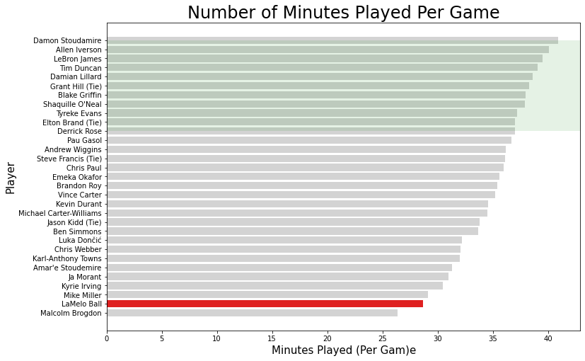

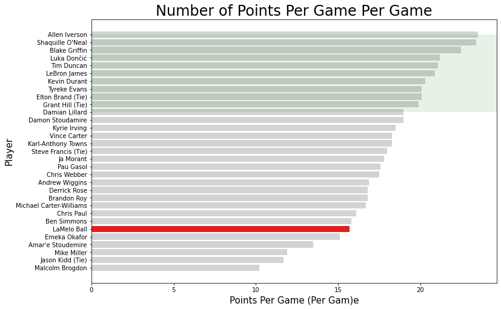

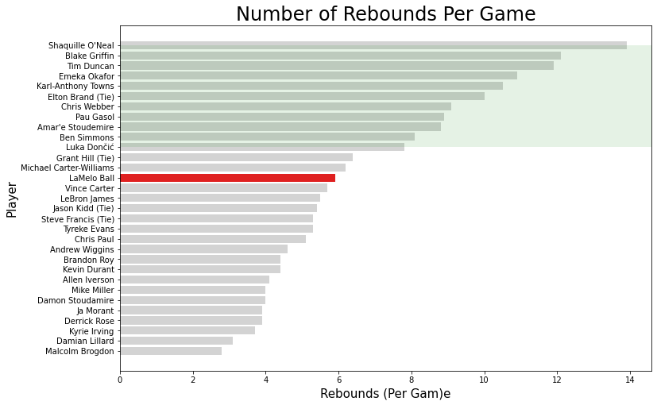

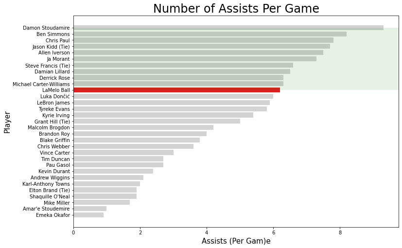

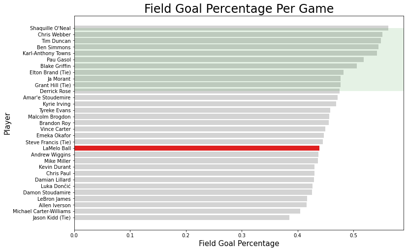

```python
# this is the stat list, along with the names for each one when graphing
stat_list = [['MP', 'Minutes Played'], \
             ['PTS', 'Points Per Game'], \
             ['TRB', 'Rebounds'], \
             ['AST', 'Assists'], \
             ['FG%','Field Goal Percentage']]

# iterates through each stat and creates a bar plot
for stat in stat_list:
    fig_dims = (12, 8)
    fig, ax = plt.subplots(figsize=fig_dims)
    df_sort = df.sort_values(stat[0], ascending=False)
    clrs = []

    # makes LaMelo red and everyone else grey
    for x in df_sort['Player']:
        if x == 'LaMelo Ball':
            clrs.append('red')
        else:
            clrs.append('lightgrey')

    sns.barplot(data=df_sort, x=stat[0], y='Player', palette=clrs)

    if stat[1] == 'Field Goal Percentage':
        plt.xlabel(stat[1], size=15)
        plt.title(stat[1]+" Per Game", size=24)
    else:
        plt.xlabel(stat[1] + " (Per Gam)e", size=15)
        plt.title("Number of " + stat[1] + " Per Game", size=24)

    # label y-axis
    plt.ylabel("Player", size=15)

    # green background
    ax.axhspan(0, 10, facecolor='green', alpha=0.1)
```

I show the statistics for all the players in each category. The red line shows LaMelo Ball's statistics, and the green background shows the top 10 players of the plot.

At first glance this data does not appear to favor the idea that LaMelo Ball lives up the hype. We see that Ball is around average in rebounds, assists, and field goal percentage, and that he is in the bottom 20% for points per game. Like stated above, to be considered living up to the hype means consistently being in the top 10 for each category.

However, from the first graph, we see that Lamelo is 2nd to last in minutes played per game. This statistic is integral for our analysis, since the number of minutes has a direct correlation to the rest of the data. I predict that playing more minutes has an effect on statistice. While I believe field goal percentage is not effected, when a player is on the court for a longer amount of time, they have more chances of scoring, rebounding, and assisting.

## OLS Regression

I predicted that the minutes played on the court has an effect on the number of points, rebounds, and assists a player can record. In order to see if that is true, I will create a OLS Regression model. This will allow me to see whether minutes played has effect on these statistics. I will create 4 OLS Regression models, each one letting Minutes Played be the independent variable, while the statistics we want to compare will be the independent variables.

```python
# Create OLS Regression model for points, rebounds, assists, field goal percentage
# as the dependent variables and minutes played as the dependent variable

stat_lst = ["PTS","TRB","AST", "FG%"]
for i in stat_lst:
    x = df[i]
    y = df['MP']
    model = sm.OLS(x,y)
    fit = model.fit()
    print(fit.summary())
```

```
                                 OLS Regression Results
=======================================================================================
Dep. Variable:                    PTS   R-squared (uncentered):                   0.983
Model:                            OLS   Adj. R-squared (uncentered):              0.982
Method:                 Least Squares   F-statistic:                              1711.
Date:                Sun, 16 May 2021   Prob (F-statistic):                    5.09e-28
Time:                        12:47:11   Log-Likelihood:                         -70.912
No. Observations:                  31   AIC:                                      143.8
Df Residuals:                      30   BIC:                                      145.3
Df Model:                           1
Covariance Type:            nonrobust
==============================================================================
                 coef    std err          t      P>|t|      [0.025      0.975]
------------------------------------------------------------------------------
MP             0.5119      0.012     41.368      0.000       0.487       0.537
==============================================================================
Omnibus:                        0.179   Durbin-Watson:                   1.605
Prob(Omnibus):                  0.914   Jarque-Bera (JB):                0.389
Skew:                          -0.058   Prob(JB):                        0.823
Kurtosis:                       2.464   Cond. No.                         1.00
==============================================================================

Notes:
[1] R² is computed without centering (uncentered) since the model does not contain a constant.
[2] Standard Errors assume that the covariance matrix of the errors is correctly specified.
                                 OLS Regression Results
=======================================================================================
Dep. Variable:                    TRB   R-squared (uncentered):                   0.840
Model:                            OLS   Adj. R-squared (uncentered):              0.835
Method:                 Least Squares   F-statistic:                              157.4
Date:                Sun, 16 May 2021   Prob (F-statistic):                    1.82e-13
Time:                        12:47:11   Log-Likelihood:                         -77.050
No. Observations:                  31   AIC:                                      156.1
Df Residuals:                      30   BIC:                                      157.5
Df Model:                           1
Covariance Type:            nonrobust
==============================================================================
                 coef    std err          t      P>|t|      [0.025      0.975]
------------------------------------------------------------------------------
MP             0.1892      0.015     12.547      0.000       0.158       0.220
```

[output cut: 45 more lines]

```
Covariance Type:            nonrobust
==============================================================================
                 coef    std err          t      P>|t|      [0.025      0.975]
------------------------------------------------------------------------------
MP             0.0132      0.000     38.371      0.000       0.012       0.014
==============================================================================
Omnibus:                        0.988   Durbin-Watson:                   1.243
Prob(Omnibus):                  0.610   Jarque-Bera (JB):                0.847
Skew:                           0.119   Prob(JB):                        0.655
Kurtosis:                       2.226   Cond. No.                         1.00
==============================================================================

Notes:
[1] R² is computed without centering (uncentered) since the model does not contain a constant.
[2] Standard Errors assume that the covariance matrix of the errors is correctly specified.
```

From the OLS Regression models, my predictions prove to be correct, along with a new discovery. Since the P-value is 0 for ever statistic (Points, Rebounds, Assists, FG%), which is less than the alpha value of 0.05, the relationship between them is statistically significant.

We learn that the coeffecients are as follows:  
Points = 0.5119  
Rebounds = 0.1893  
Assists = 0.1341  
Field Goal Percentage = 0.0132

The coeffecient tells us the positive or negative correlation between the independent and dependent varibale. Since they are all positive, we see that there is a positive for each one. The number of points has the highest correlation, while rebounds and assists have similar results. The field goal percentage is surprising, since I originally thought that minutes played would have no effect on their minutes played. While the coeffecient is small, we still see there is a small positive correlation between minutes played and field goal percentage. My predication may have been true if I were using data of everyone in the league. However, since I am only comparing the best rookie players of the league of every year, we see that the more minutes they play, the more experience they get to be comfortable shooting.

# Per 36-Minute

First I will create the statistics to be correlated to per 36 minutes. The reason for doing this is that the NBA usually either creates ratings based off per-36 or per-40 minutes. I arbitrarily chose the per-36 minutes statistic to use for my dataframe. Using either one will have no effect on the output. The website that I retrieved the data does not contain the per 36-minute statistics for each player, so I will do the manipulation myself. I will be using the formula provided by https://www.nbastuffer.com/analytics101/per-minute-ratings/#:~:text=Per%2Dminute%20ratings%20are%20calculated,he'd%20play%2036%20minutes. This website shows the formula for per 36-minutes is (36 * statistic)/minutes, so I will use this in my calculations.

```python
# Manipulating the data using the formula above and then add it to dataframe

per_thirtysix = []
temp_arr = []
pts_thritysix = []
rbs_thritysix = []
asts_thritysix = []
fg_thritysix = []

# manipulating data
for i,stats in df.iterrows():
    pts_thritysix.append(float(format((float(36.0*stats['PTS']))/(stats['MP']),".1f")))
    rbs_thritysix.append(float(format((float(36.0*stats['TRB']))/(stats['MP']),".1f")))
    asts_thritysix.append(float(format((float(36.0*stats['AST']))/(stats['MP']),".1f")))
    fg_thritysix.append(float(format((float(36.0*stats['FG%']))/(stats['MP']),".3f")))

# add to dataframe
df['36_PTS'] = pts_thritysix
df['36_RB'] = rbs_thritysix
df['36_AST'] = asts_thritysix
df['36_FG%'] = fg_thritysix
```

```python
# Lets see dataframe looks like
df.head(3)
```

|  | Season | Player | MP | PTS | TRB | AST | FG% | 36_PTS | 36_RB | 36_AST | 36_FG% |
| --- | --- | --- | --- | --- | --- | --- | --- | --- | --- | --- | --- |
| 0 | 2020-21 | LaMelo Ball | 28.7 | 15.7 | 5.9 | 6.2 | 0.439 | 19.7 | 7.4 | 7.8 | 0.551 |
| 1 | 2019-20 | Ja Morant | 31.0 | 17.8 | 3.9 | 7.3 | 0.477 | 20.7 | 4.5 | 8.5 | 0.554 |
| 2 | 2018-19 | Luka Dončić | 32.2 | 21.2 | 7.8 | 6.0 | 0.427 | 23.7 | 8.7 | 6.7 | 0.477 |

Now that we have the per 36, we can plot the data with the data representing the true value of each player's statistics.

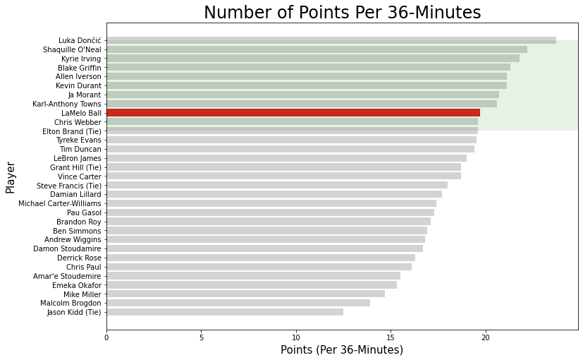

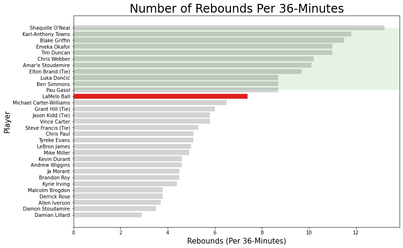

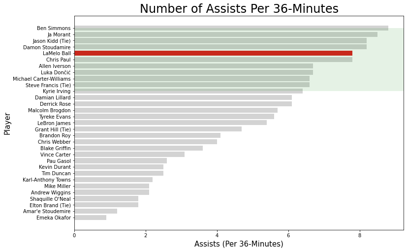

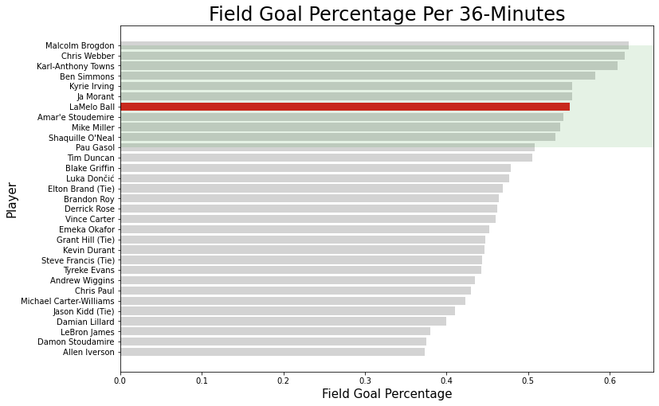

```python
# list of stats for per 36-min
stat_list = [['36_PTS', 'Points'], \
             ['36_RB', 'Rebounds'], \
             ['36_AST', 'Assists'], \
             ['36_FG%','Field Goal Percentage']]

for stat in stat_list:
    fig_dims = (12, 8)
    fig, ax = plt.subplots(figsize=fig_dims)

    # sorts values to highest is on the top
    df_sort = df.sort_values(stat[0], ascending=False)
    clrs = []

    # makes LaMelo red and everyone else grey
    for x in df_sort['Player']:
        if x == 'LaMelo Ball':
            clrs.append('red')
        else:
            clrs.append('lightgrey')

    sns.barplot(data=df_sort, y='Player', x=stat[0], palette=clrs)

    # create different title and x-axis for field goal percentage
    if stat[1] == 'Field Goal Percentage':
        plt.xlabel(stat[1], size=15)
        plt.title(stat[1]+" Per 36-Minutes", size=24)
    else:
        plt.xlabel(stat[1] + " (Per 36-Minutes)", size=15)
        plt.title("Number of " + stat[1] + " Per 36-Minutes", size=24)

    # label y axis
    plt.ylabel("Player", size=15)

    # make background green
    ax.axhspan(0, 10, facecolor='green', alpha=0.1)
```

I show the per 36-minute statistics for all the players in each category. The red line shows LaMelo Ball's statistics, and the green background shows the top 10 players of the plot.

Wow. After adjusting the statistics to take minutes played into consideration, we have a different story than what we originally saw from the data. LaMelo Ball is in the top 10 of every category except for rebounds, in which he is 2 slots below the cutoff.

# Conclusion: Does LaMelo Ball Deserve to Have the Hype?

In short: yes.

We saw that in the past, the best players had the worst statistics their rookie season - which makes sense. They are coming into the league for the first time and it takes time to get into the rythm of playing at such a high level. Therefore, I chose to compare LaMelo Ball to the best rookies of the past 30 years. When first looking at how LaMelo Ball compares to these players, we saw that he ranged from low to mediocre in Points, Rebounds per Game, Assists per Game, and Field Goal Percentage. While this may have been the end of the story, we saw that he was in the bottom 20% in minutes played. As we saw from the OLS Regression models, all these categories have a positive correlation with minutes played. This also makes sense - the more time a player has on the court, the more opportunity they have to add to the stat box. I then adjusted all their statistics to evaluate the players on their performance per 36 minutes. This showed a complete different story than the previous plots. In every category, LaMelo Ball is in the top 10, except for rebounds. Even in the rebound category, LaMelo Ball was 12th on the list. This is a very impressive. It is important to remember that the players that I comparing with LaMelo Ball are Rookie of the Year recipients. They were supposedly the best rookie players of that year. The fact that LaMelo Ball is almost in the top 10 of these players is astonishing. For this reason, LaMelo Ball deserves to have the hype.

While LaMell Ball is projected to be one of the best players in the NBA as he progresses through his career based off his rookie statistics alone, there is an imporant detail to note. Basketball is full intangibles, specifically with injuries. Injuries have plagued some of the best players into becoming mediocre ones after the surgery. Being a great player one year will not automatically translate into becoming a superstar.

Even so, LaMelo had a great season this year and it will be fun to see his development and growth in the next few years.